# Speech Input Stats

June 27, 2019

# 1 Data Parsing

## 1.1 Loading Data

Filtering out invalid participants (9, 10, and 14).

```r
data_c = read.csv("parse_more.csv",sep=",") %>% filter(!participantNo %in% c(9, 10, 14))
data_c = data_c[,!names(data_c) %in% c("incorrect_fixed", "fixes", "correct", "inf", "correctMsg", "gMsg")]
data_c$totalTime = data_c$inputTime + data_c$prepTime
data_c.kbd = filter(data_c, inputType=="Keyboard")
data_c.sr = filter(data_c, inputType=="Speech")

data_t = read.csv("parse_more_trans.csv",sep=",")
data_t = data_t[,!names(data_t) %in% c("incorrect_fixed", "fixes", "correct", "inf", "msg", "orgMsg")]
data_t$totalTime = data_t$inputTime + data_t$prepTime
data_t$setNum = substr(data_t$setNum, 1, 1)
data_t.kbd = filter(data_t, inputType=="Keyboard")
data_t.sr = filter(data_t, inputType=="Speech")
```

## 1.2 Outlier Culling

I removed values outside of 3 standard deviations for the means of each task x method combination, for totalTime.

22 outliers identified for composition (2.04% of trials)

26 outliers identified for transcription (2.32% of trials)

## 1.3 Data Aggregation

Aggregating the cleaned data

```r
data = bind_rows(data_t.clean, data_c.clean)

data.group = summarize(group_by(data, participantNo, inputType, taskType, setNum), meanInputTime = mean(inputTime), meanPrepTime = mean(prepTime), meanEntryTime = mean(entryTime), meanTotalTime = mean(totalTime), meanLen = mean(msgLen), meanWpm = mean(wpm), mean_uer = mean(uncorrected_error_rate), mean_cer= mean(corrected_error_rate), mean_bd = mean(bandwidth), meanCorrTime = mean(corrTime))

data.stats = dplyr::bind_rows(data_c.clean, data_t.clean) %>%
  group_by(inputType, taskType) %>%
  summarize(mIT = mean(inputTime), cuIT = ci(inputTime)[3], clIT = ci(inputTime)[2], sdIT = sd(inputTime),
            mPT = mean(prepTime), cuPT = ci(prepTime)[3], clPT = ci(prepTime)[2], sdPT = sd(prepTime),
            mET = mean(entryTime), cuET=ci(entryTime)[3], clET = ci(entryTime)[2], sdET = sd(entryTime),
            mTT = mean(totalTime), cuTT = ci(totalTime)[3], clTT = ci(totalTime)[2], sdTT = sd(totalTime),
            mCT = mean(corrTime), cuCT = ci(corrTime)[3], clCT = ci(corrTime)[2], sdCT = sd(corrTime),
            mWpm = mean(wpm), cuWpm = ci(wpm)[3], clWpm = ci(wpm)[2], sdWpm = sd(wpm),
            m_uer = mean(uncorrected_error_rate), cu_uer = ci(uncorrected_error_rate)[3], cl_uer = ci(uncorrected_error_rate)[2], sd_uer = sd(uncorrected_error_rate),
            m_cer= mean(corrected_error_rate), cu_cer = ci(corrected_error_rate)[3], cl_cer = ci(corrected_error_rate)[2], sd_cer = sd(corrected_error_rate),
            m_bd = mean(bandwidth), cuBD = ci(bandwidth)[3], clBD = ci(bandwidth)[2], sdBD = sd(bandwidth))

data.long = melt(data.group, id = c("participantNo", "inputType", "taskType", "setNum", "meanInputTime", "meanPrepTime", "meanWpm", "meanTotalTime", "meanEntryTime", "meanLen", "mean_uer", "mean_cer", "mean_bd", "meanCorrTime"))

data.long$participantNo <- factor(data.long$participantNo)
data.long$inputType <- factor(data.long$inputType)

data.long.c = filter(data.long, taskType == "Composition")
data.long.c = data.long.c[,!names(data.long.c) %in% c("taskType")]

data.long.t = filter(data.long, taskType == "Transcription")
data.long.t = data.long.t[,!names(data.long.t) %in% c("taskType")]

data.long$setNum <- factor(data.long$setNum)
data.long$taskType <- factor(data.long$taskType)

data.long.c$setNum <- factor(data.long.c$setNum)
data.long.t$setNum <- factor(data.long.t$setNum)
```

Output data stats to a Latex table

Psych, this didn’t actually work that well….

```r
#data.stats.i = unite(data.stats, "ti", taskType, inputType)
#data.stats.i = data.stats.i[order(data.stats.i$ti),]

#data.tbl <- dplyr::select(data.stats.i, ti, mTT, sdTT, mIT, sdIT, mPT, sdPT, mET, sdET, mWpm, sdWpm, m_uer, sd_uer, m_cer, sd_cer) %>% t %>% as.data.frame()

#print(xtable(data.tbl, type = "latex"), file = "autogen/table.tex")
```

# 2 Input Time

## 2.1 Chart

```r
kable(dplyr::select(data.stats, inputType, taskType, mIT, sdIT))
```

| inputType | taskType | mIT | sdIT |
| --- | --- | --- | --- |
| Keyboard | Composition | 23907.651 | 12953.840 |
| Keyboard | Transcription | 15774.973 | 6666.367 |
| Speech | Composition | 8163.963 | 6777.923 |
| Speech | Transcription | 5743.435 | 4240.649 |

## 2.2 Bar Graph

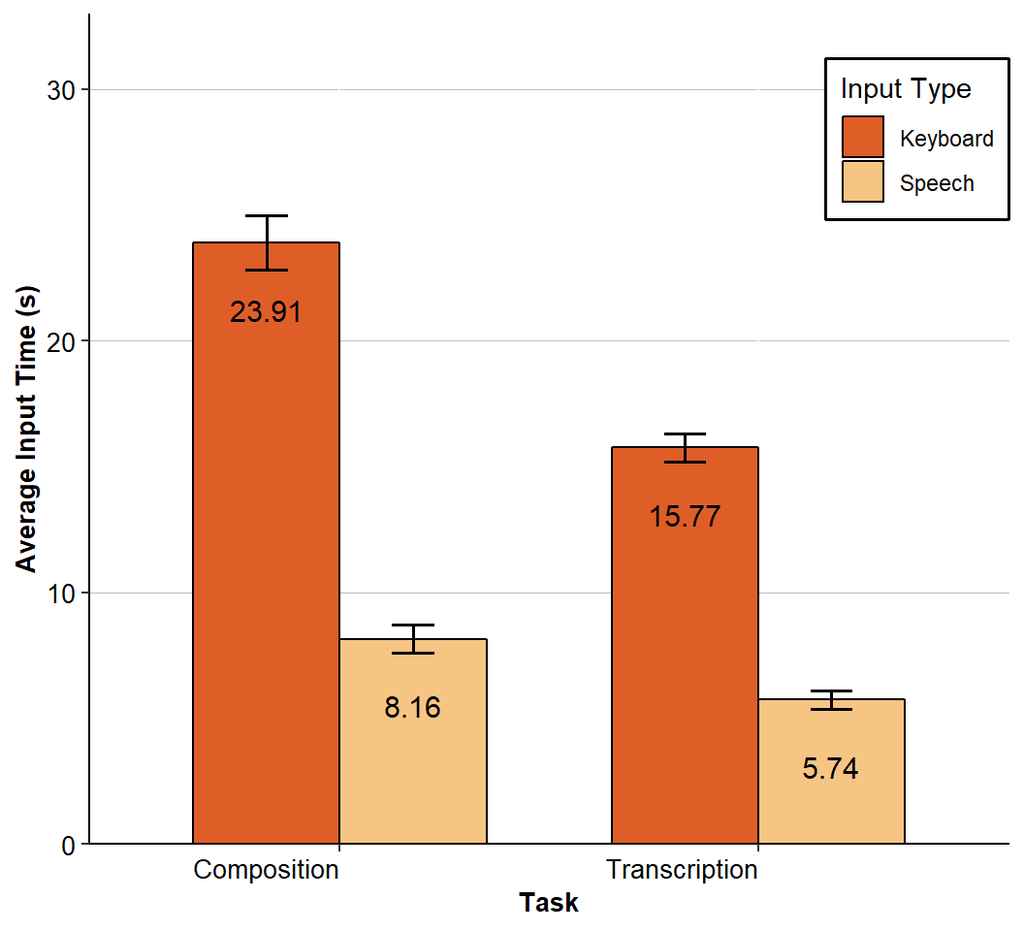

```r
createPlot(data.stats, "mIT", "clIT", "cuIT", 3.5, 0.9, 0.85, "Average Input Time (s)")
```

```r
ggsave("autogen/inputtime.pdf")
```

## 2.3 Effects of SetNum

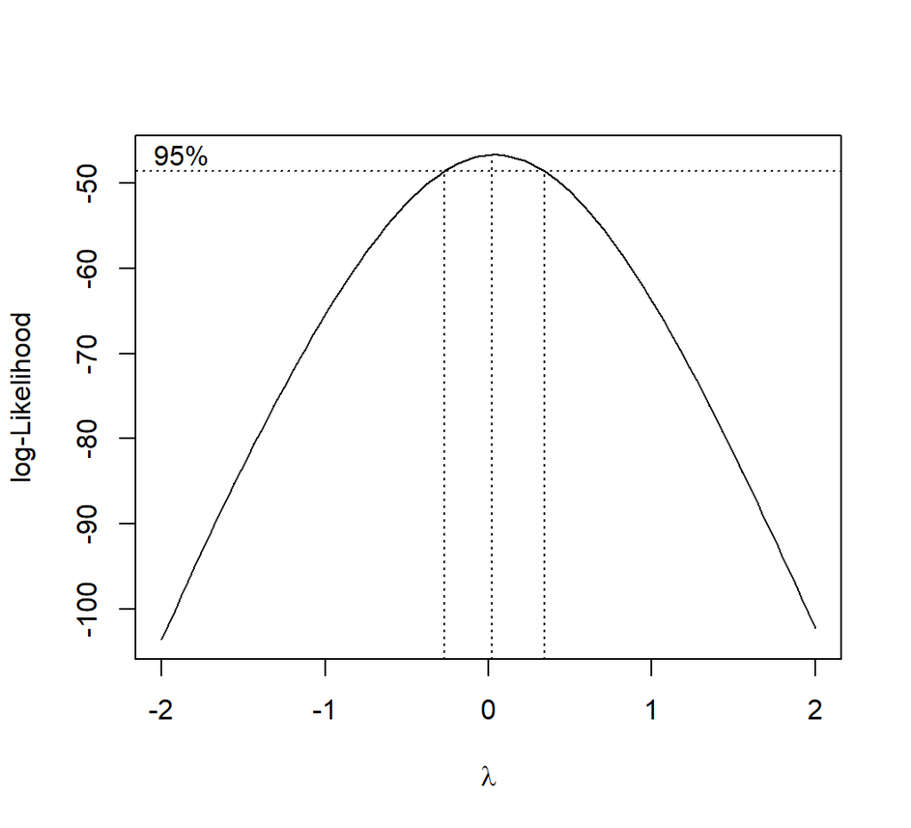

```r
boxcox(meanInputTime ~ inputType*setNum, data=data.long.c, plotit=T)
```

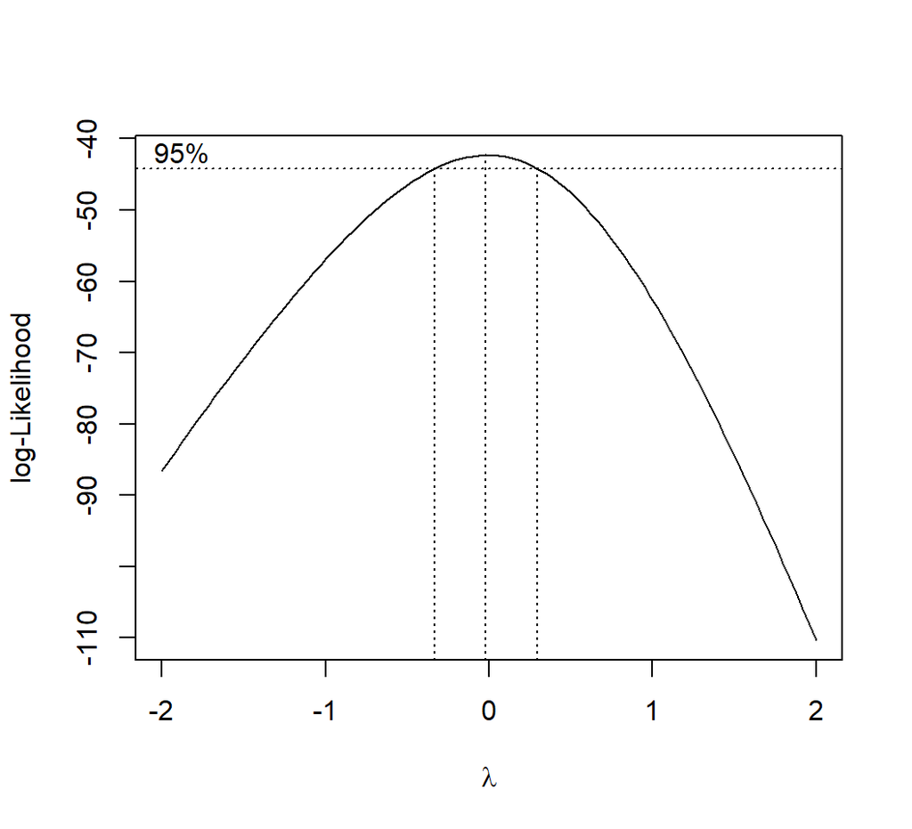

```r
boxcox(meanInputTime ~ inputType*setNum, data=data.long.t, plotit=T)
```

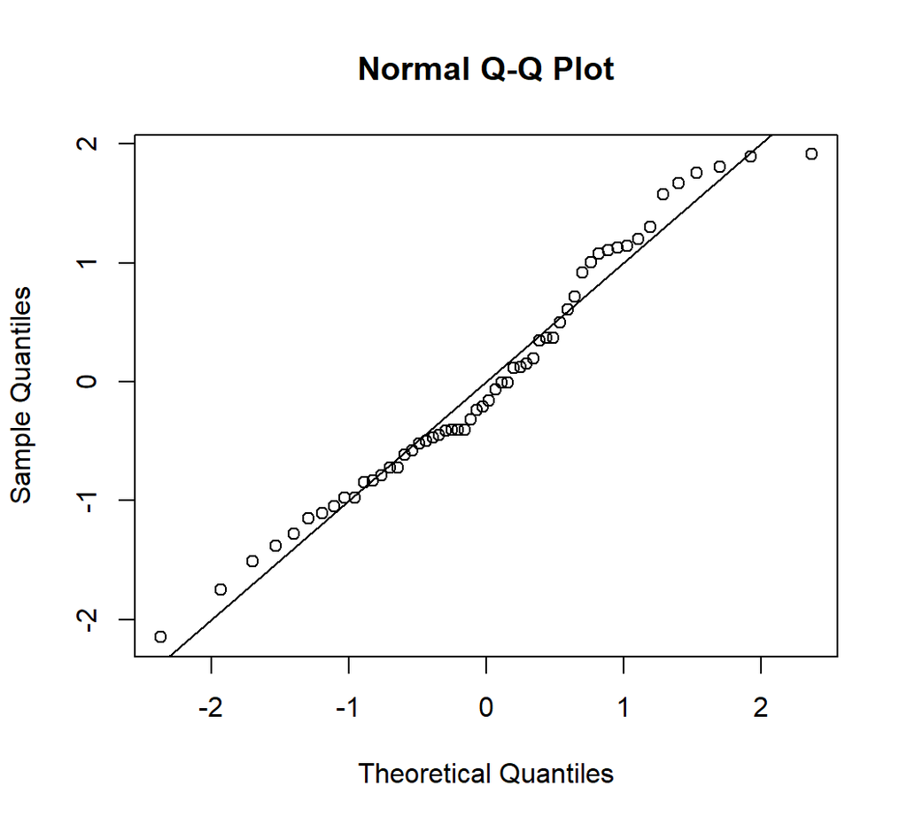

```r
datatr.c = data.long.c %>% mutate(meanInputTime = log(meanInputTime))
datatr.t = data.long.t %>% mutate(meanInputTime = log(meanInputTime))

m <- aov(meanInputTime ~ inputType*setNum, data=datatr.c)
pander(normalCheck(m))
```

Shapiro-Wilk normality test

data: res W = 0.97123, p-value = 0.1999

Shapiro-Wilk normality test: `res`

| Test statistic | P value |
| --- | --- |
| 0.9712 | 0.1999 |

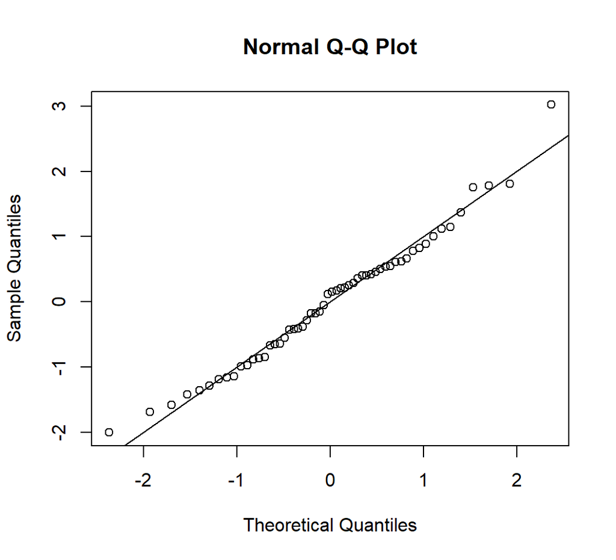

```r
m <- aov(meanInputTime ~ setNum*inputType, data=datatr.t)
pander(normalCheck(m))
```

Shapiro-Wilk normality test

data: res W = 0.98212, p-value = 0.571

Shapiro-Wilk normality test: `res`

| Test statistic | P value |
| --- | --- |
| 0.9821 | 0.571 |

Data is now normally distributed.

```r
anova = ezANOVA(datatr.c, dv=.(meanInputTime), wid=.(participantNo), within=.(setNum), detailed=TRUE)
kable(anova_apa(anova, sph_corr ="gg", es = "ges", print=FALSE))
```

| effect | text |
| --- | --- |
| (Intercept) | F(1, 27) = 34449.79, p < .001, getasq > .99 |
| setNum | F(1, 27) = 0.04, p = .848, getasq < .01 |

```r
anova = ezANOVA(datatr.t, dv=.(meanInputTime), wid=.(participantNo), within=.(setNum), detailed=TRUE)
kable(anova_apa(anova, sph_corr ="gg", es = "ges", print=FALSE))
```

| effect | text |
| --- | --- |
| (Intercept) | F(1, 27) = 45135.39, p < .001, getasq > .99 |
| setNum | F(1, 27) = 0.09, p = .772, getasq < .01 |

No significant effect of setNum.

## 2.4 Effects of Input Type and Task Type

### 2.4.1 Normality Check

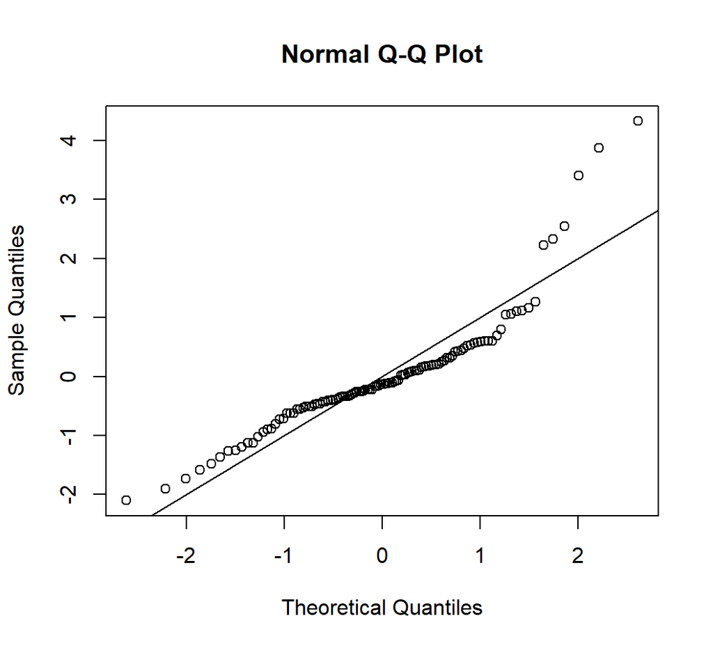

```r
m <- aov(meanInputTime ~ taskType*inputType, data=data.long)
pander(normalCheck(m))
```

Shapiro-Wilk normality test

data: res W = 0.86153, p-value = 8.006e-09

Shapiro-Wilk normality test: `res`

| Test statistic | P value |
| --- | --- |
| 0.8615 | 8.006e-09 * * * |

The data is not normally distributed.

### 2.4.2 Box-Cox Transformation

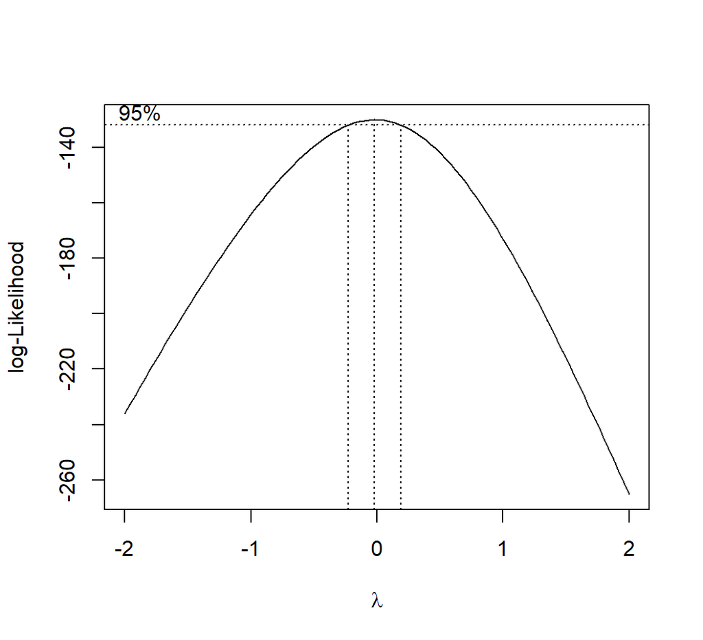

```r
boxcox(meanInputTime ~ inputType*taskType, data=data.long, plotit=T)
```

An effective lambda value is 0.0 (a.k.a, a log transformation).

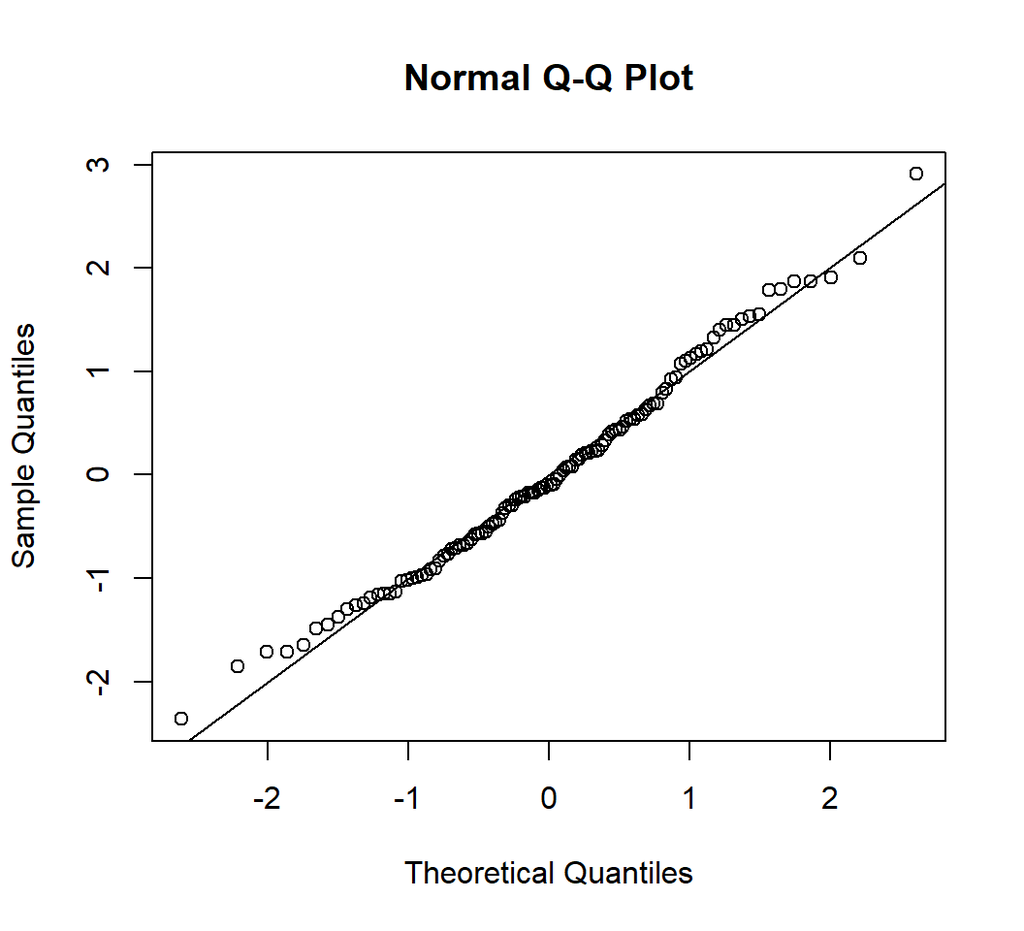

```r
datatr = data.long %>%
    mutate(meanInputTime = log(meanInputTime))

m <- aov(meanInputTime ~ taskType*inputType, data=datatr)
pander(normalCheck(m))
```

Shapiro-Wilk normality test

data: res W = 0.98949, p-value = 0.5413

Shapiro-Wilk normality test: `res`

| Test statistic | P value |
| --- | --- |
| 0.9895 | 0.5413 |

### 2.4.3 Repeated measures ANOVA on transformed data

```r
anova = ezANOVA(datatr, dv=.(meanInputTime), wid=.(participantNo), within=.(inputType,taskType), detailed=TRUE)
# kable(anova$`Mauchly's Test for Sphericity`)
# kable(anova$`Sphericity Corrections`)
# kable(anova$ANOVA)
anova_apa = anova_apa(anova, sph_corr ="gg", es = "ges", print=FALSE)
input = anova_apa$text[2]
task = anova_apa$text[3]
kable(anova_apa)
```

| effect | text |
| --- | --- |
| (Intercept) | F(1, 27) = 50661.87, p < .001, getasq > .99 |
| inputType | F(1, 27) = 394.46, p < .001, getasq = .75 |
| taskType | F(1, 27) = 64.79, p < .001, getasq = .27 |
| inputType:taskType | F(1, 27) = 0.17, p = .682, getasq < .01 |

There are significant differences between input type and task type, but not the interaction between the two.

```r
# attach(datatr)
# pw <- pairwise.t.test(meanInputTime, interaction(inputType, taskType), p.adj = "bonferroni")
# detach(datatr)
# kable(pw$p.value)
```

```python
s = "There were significant differences between \\f{speech} and \\f{keyboard}, and between \\f{composition} and \\f{transcription} on Box-Cox transformed \\m{Input Time} (%s) (%s)." % (parseAnova(r.input), parseAnova(r.task))
writeToFile(s, "inputtime.tex")
```

# 3 Prep Time

## 3.1 Chart

```r
kable(dplyr::select(data.stats, inputType, taskType, mPT, sdPT))
```

| inputType | taskType | mPT | sdPT |
| --- | --- | --- | --- |
| Keyboard | Composition | 5277.724 | 5358.9547 |
| Keyboard | Transcription | 1149.166 | 637.9827 |
| Speech | Composition | 12640.854 | 8445.5427 |
| Speech | Transcription | 3503.583 | 1324.1996 |

## 3.2 Bar Graph

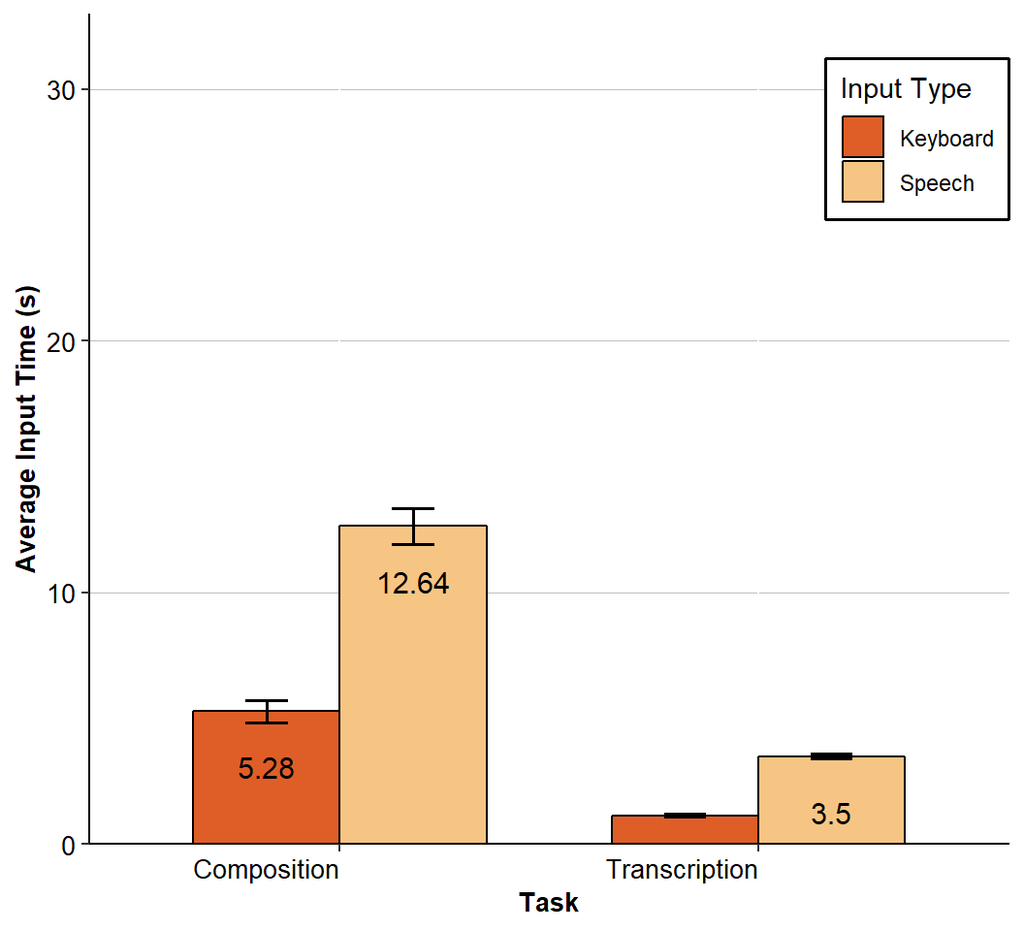

```r
# ggplot(data.stats, aes(x=taskType, y=mPT, color=inputType)) +
#   geom_line(aes(group=inputType), size=0.9) +
#   geom_point() +
#   geom_errorbar(aes(ymin = clPT, ymax = cuPT), width = 0.1, size = 0.7) +
#   scale_x_discrete(name="Task") +
#   scale_y_continuous(name="Average Prep Time (ms)")
createPlot(data.stats, "mPT", "clPT", "cuPT", 3, 0.9, 0.85, "Average Input Time (s)")
```

## 3.3 Effects of SetNum

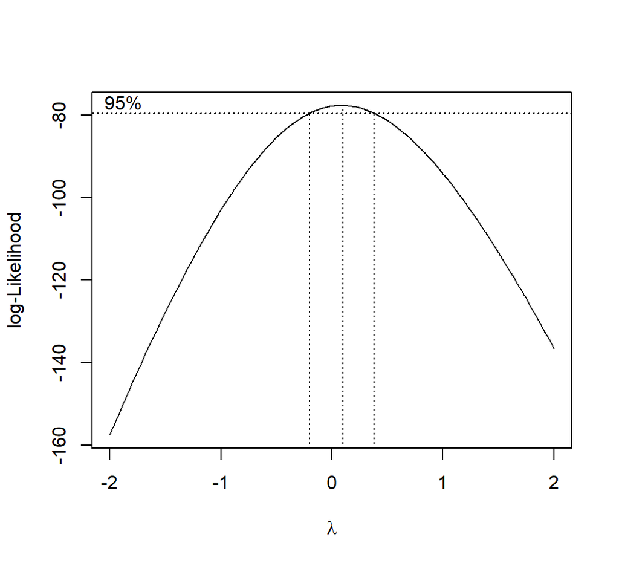

```r
boxcox(meanPrepTime ~ inputType*setNum, data=data.long.c, plotit=T)
```

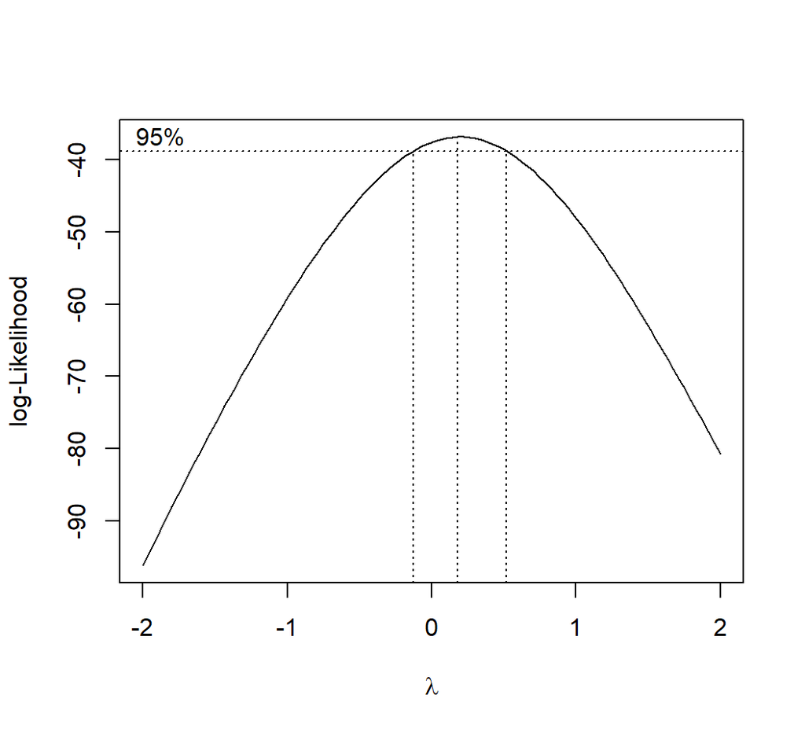

```r
boxcox(meanPrepTime ~ inputType*setNum, data=data.long.t, plotit=T)
```

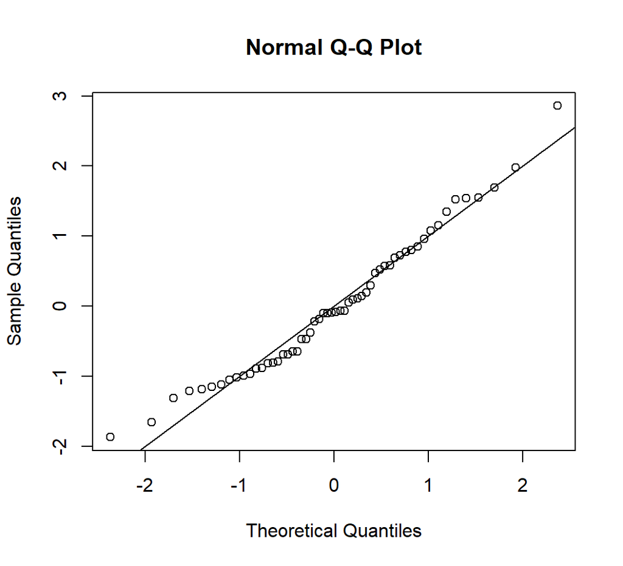

```r
datatr.c = data.long.c %>% mutate(meanPrepTime = meanPrepTime^(0.1))
datatr.t = data.long.t %>% mutate(meanPrepTime = meanPrepTime^(0.1))

m <- aov(meanPrepTime ~ inputType*setNum, data=datatr.c)
pander(normalCheck(m))
```

Shapiro-Wilk normality test

data: res W = 0.97249, p-value = 0.2279

Shapiro-Wilk normality test: `res`

| Test statistic | P value |
| --- | --- |
| 0.9725 | 0.2279 |

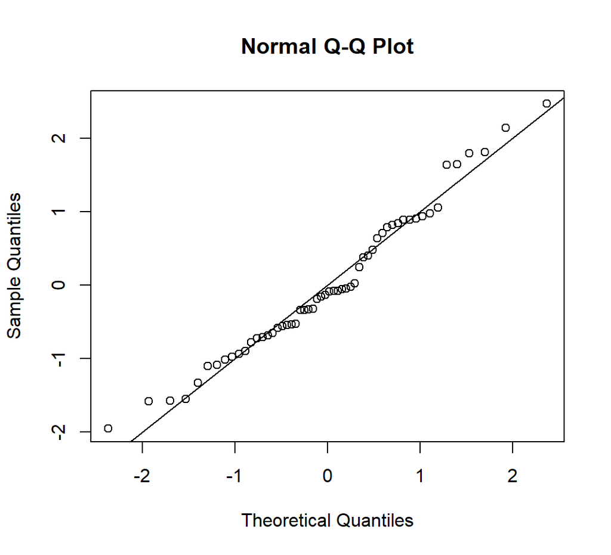

```r
m <- aov(meanPrepTime ~ setNum*inputType, data=datatr.t)
pander(normalCheck(m))
```

Shapiro-Wilk normality test

data: res W = 0.97418, p-value = 0.2711

Shapiro-Wilk normality test: `res`

| Test statistic | P value |
| --- | --- |
| 0.9742 | 0.2711 |

```r
anova = ezANOVA(datatr.c, dv=.(meanPrepTime), wid=.(participantNo), within=.(setNum), detailed=TRUE)
kable(anova_apa(anova, sph_corr ="gg", es = "ges", print=FALSE))
```

| effect | text |
| --- | --- |
| (Intercept) | F(1, 27) = 13282.44, p < .001, getasq = .99 |
| setNum | F(1, 27) = 0.37, p = .548, getasq < .01 |

```r
anova = ezANOVA(datatr.t, dv=.(meanPrepTime), wid=.(participantNo), within=.(setNum), detailed=TRUE)
kable(anova_apa(anova, sph_corr ="gg", es = "ges", print=FALSE))
```

| effect | text |
| --- | --- |
| (Intercept) | F(1, 27) = 52920.73, p < .001, getasq > .99 |
| setNum | F(1, 27) = 0.04, p = .849, getasq < .01 |

No significant effect of setNum on prep time.

## 3.4 Effects of Input Type and Task Type

### 3.4.1 Normality Check

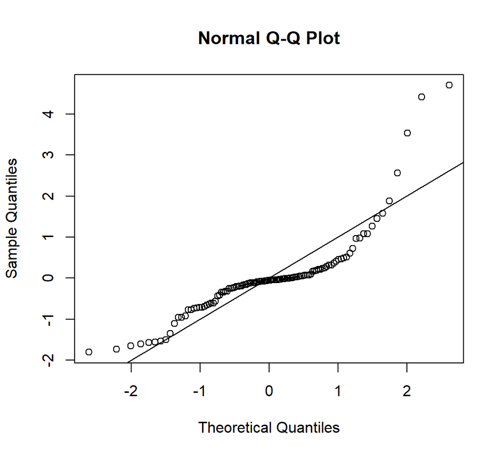

```r
m <- aov(meanPrepTime ~ taskType*inputType, data=data.long)
pander(normalCheck(m))
```

Shapiro-Wilk normality test

data: res W = 0.79505, p-value = 3.386e-11

Shapiro-Wilk normality test: `res`

| Test statistic | P value |
| --- | --- |
| 0.7951 | 3.386e-11 * * * |

The data is not normally distributed.

### 3.4.2 Box-Cox Transformation

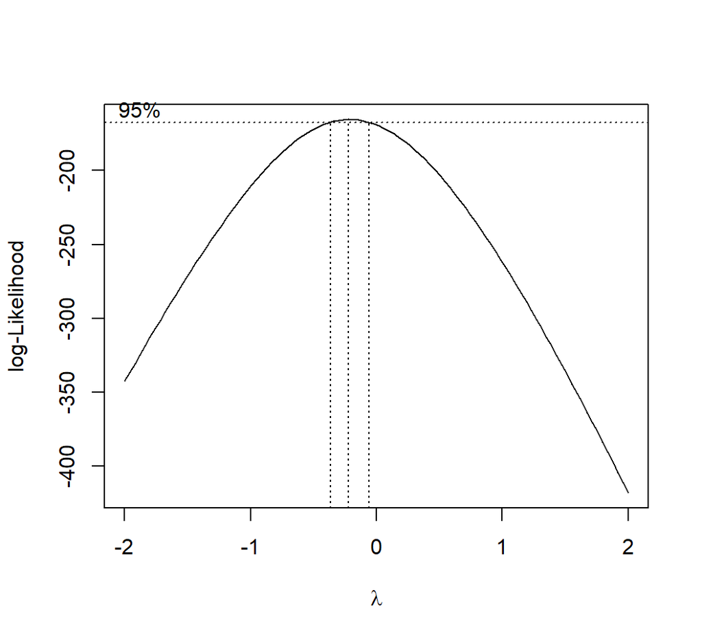

```r
boxcox(meanPrepTime ~ inputType*taskType, data=data.long, plotit=T)
```

An effective lambda value is -0.1.

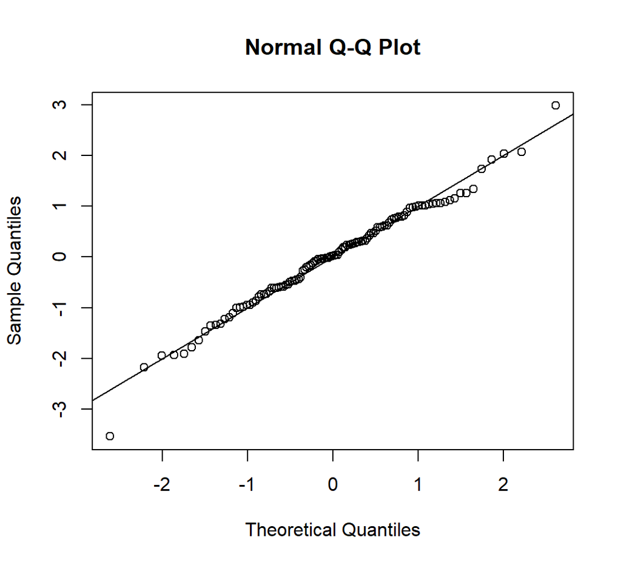

```r
datatr = data.long %>%
    mutate(meanPrepTime = meanPrepTime^(-0.1))

m <- aov(meanPrepTime ~ taskType*inputType, data=datatr)
pander(normalCheck(m))
```

Shapiro-Wilk normality test

data: res W = 0.9862, p-value = 0.3071

Shapiro-Wilk normality test: `res`

| Test statistic | P value |
| --- | --- |
| 0.9862 | 0.3071 |

### 3.4.3 Repeated measures ANOVA on transformed data

```r
anova = ezANOVA(datatr, dv=.(meanPrepTime), wid=.(participantNo), within=.(inputType,taskType), detailed=TRUE)

# kable(anova$`Mauchly's Test for Sphericity`)
# kable(anova$`Sphericity Corrections`)
# kable(anova$ANOVA)
anova_apa = anova_apa(anova, sph_corr ="gg", es = "ges", print=FALSE)
input = anova_apa$text[2]
task = anova_apa$text[3]
inter = anova_apa$text[4]
kable(anova_apa)
```

| effect | text |
| --- | --- |
| (Intercept) | F(1, 27) = 33578.79, p < .001, getasq > .99 |
| inputType | F(1, 27) = 228.23, p < .001, getasq = .62 |
| taskType | F(1, 27) = 287.50, p < .001, getasq = .70 |
| inputType:taskType | F(1, 27) = 5.29, p = .029, getasq = .02 |

There are significant differences between input type and task type (both p < 0.01), and for the interaction between the two (p < 0.05).

### 3.4.4 Post-hoc analysis with Tukey HSD

```r
t <- TukeyHSD(m)
kable(t$`taskType:inputType`)
```

|  | diff | lwr | upr | p adj |
| --- | --- | --- | --- | --- |
| Transcription:Keyboard-Composition:Keyboard | 0.0620623 | 0.0490384 | 0.0750862 | 0.0000000 |
| Composition:Speech-Composition:Keyboard | -0.0416876 | -0.0547115 | -0.0286637 | 0.0000000 |
| Transcription:Speech-Composition:Keyboard | 0.0093600 | -0.0036640 | 0.0223839 | 0.2447325 |
| Composition:Speech-Transcription:Keyboard | -0.1037499 | -0.1167738 | -0.0907260 | 0.0000000 |
| Transcription:Speech-Transcription:Keyboard | -0.0527023 | -0.0657262 | -0.0396784 | 0.0000000 |
| Transcription:Speech-Composition:Speech | 0.0510476 | 0.0380236 | 0.0640715 | 0.0000000 |

Everything but the Transcription:Speech vs. Composition:Keyboard comparison is significant.

```python
s = "There were significant differences between \\f{speech} and \\f{keyboard} (%s), and between \\f{composition} and \\f{transcription} on Box-Cox transformed \\m{Prep Time} (%s). There was also a significant interaction between \\f{Method} and \\f{Task} (%s)" % (parseAnova(r.input), parseAnova(r.task), parseAnova(r.inter))
writeToFile(s, "preptime.tex")
```

# 4 Total Time

## 4.1 Chart

```r
kable(dplyr::select(data.stats, inputType, taskType, mTT, sdTT))
```

| inputType | taskType | mTT | sdTT |
| --- | --- | --- | --- |
| Keyboard | Composition | 29185.375 | 14928.372 |
| Keyboard | Transcription | 16924.138 | 6831.824 |
| Speech | Composition | 20804.817 | 10962.179 |
| Speech | Transcription | 9247.018 | 4523.672 |

## 4.2 Bar Graph

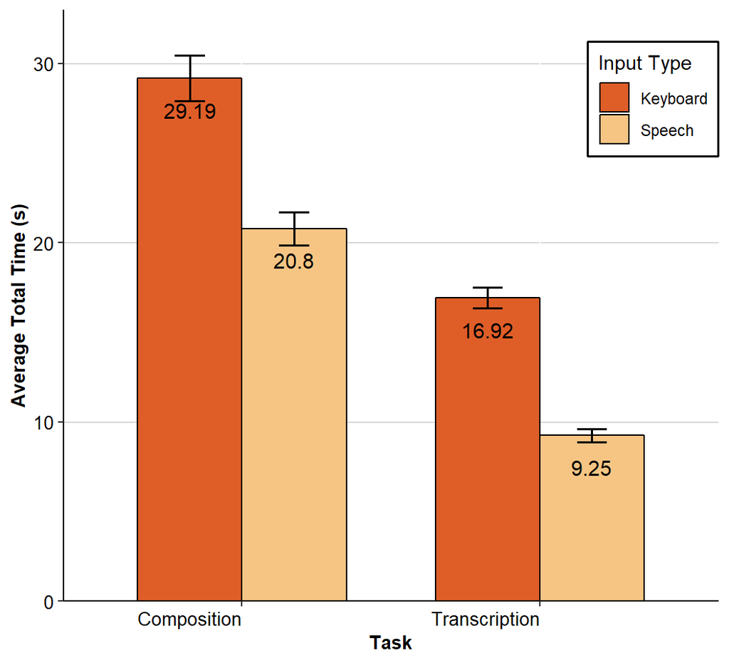

```r
# ggplot(data.stats, aes(x=taskType, y=mTT, color=inputType)) +
#   geom_line(aes(group=inputType), size=0.9) +
#   geom_point() +
#   geom_errorbar(aes(ymin = clTT, ymax = cuTT), width = 0.1, size = 0.7) +
#   scale_x_discrete(name="Task") +
#   scale_y_continuous(name="Average Total Time (ms)")
createPlot(data.stats, "mTT", "clTT", "cuTT", 2.5, 0.9, 0.85, "Average Total Time (s)")
```

## 4.3 Effects of SetNum

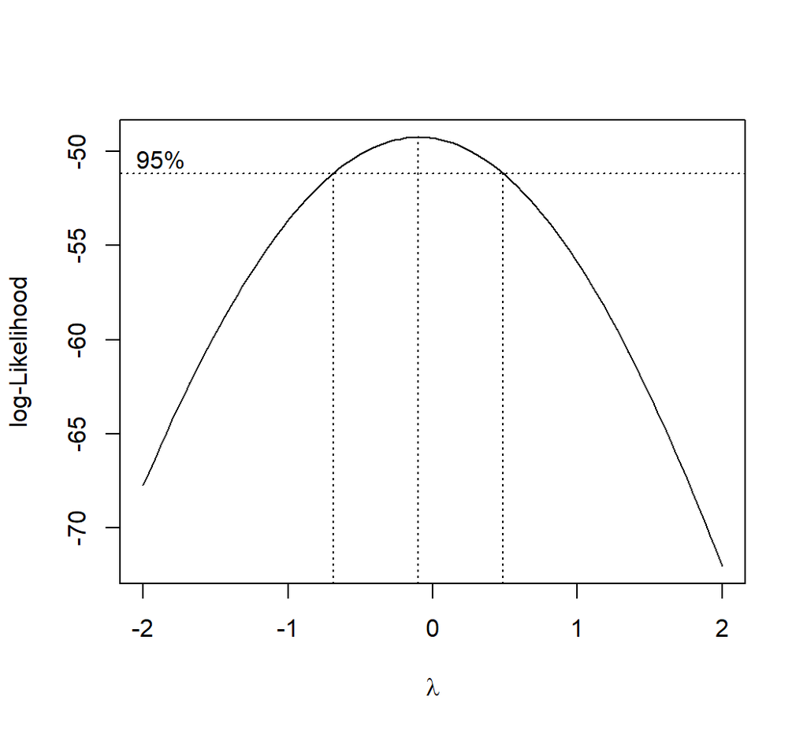

```r
boxcox(meanTotalTime ~ inputType*setNum, data=data.long.c, plotit=T)
```

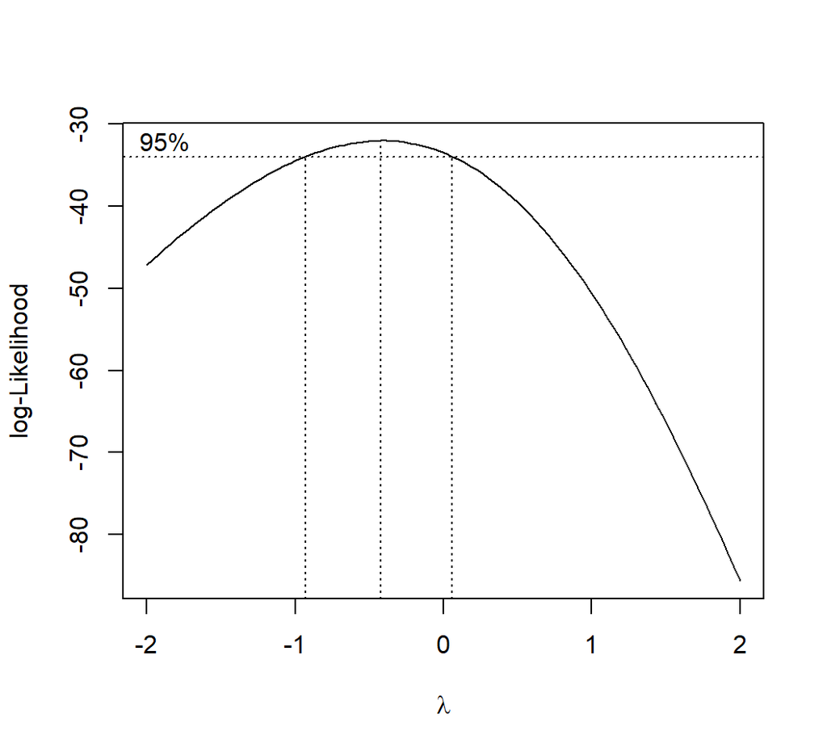

```r
boxcox(meanTotalTime ~ inputType*setNum, data=data.long.t, plotit=T)
```

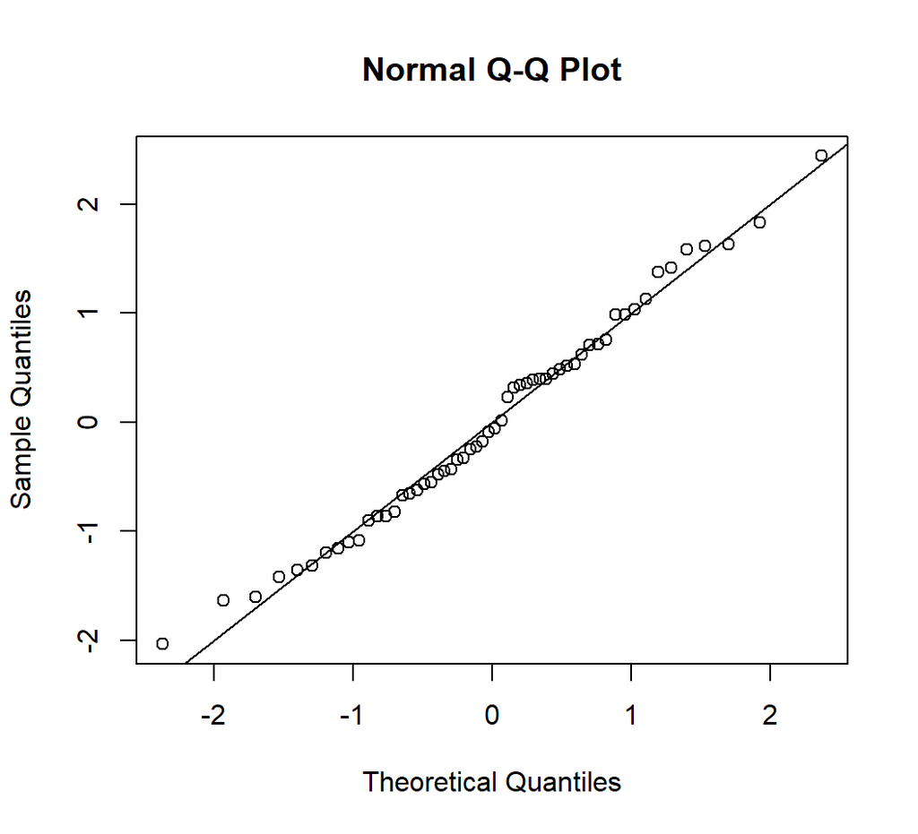

```r
datatr.c = data.long.c %>% mutate(meanTotalTime = log(meanTotalTime))
datatr.t = data.long.t %>% mutate(meanTotalTime = meanTotalTime^(-0.5))

m <- aov(meanTotalTime ~ inputType*setNum, data=datatr.c)
pander(normalCheck(m))
```

Shapiro-Wilk normality test

data: res W = 0.98657, p-value = 0.7862

Shapiro-Wilk normality test: `res`

| Test statistic | P value |
| --- | --- |
| 0.9866 | 0.7862 |

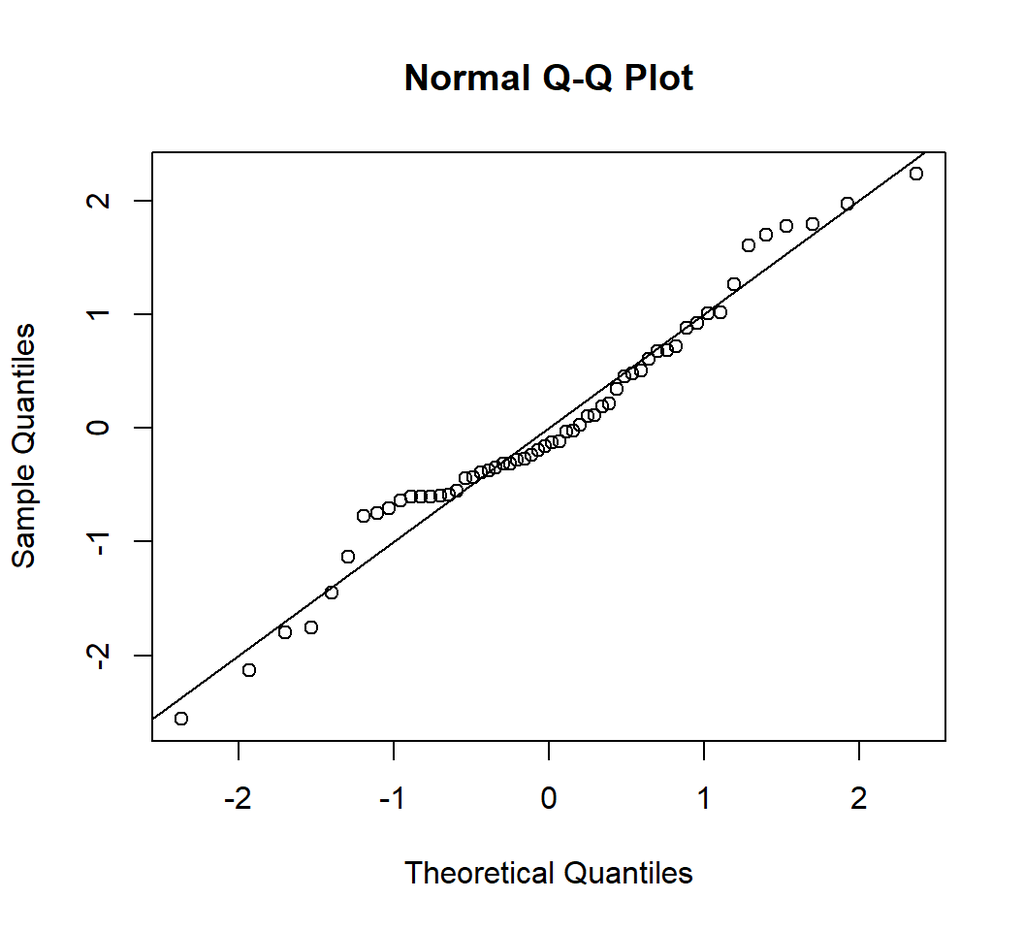

```r
m <- aov(meanTotalTime ~ setNum*inputType, data=datatr.t)
pander(normalCheck(m))
```

Shapiro-Wilk normality test

data: res W = 0.97235, p-value = 0.2246

Shapiro-Wilk normality test: `res`

| Test statistic | P value |
| --- | --- |
| 0.9723 | 0.2246 |

```r
anova = ezANOVA(datatr.c, dv=.(meanTotalTime), wid=.(participantNo), within=.(setNum), detailed=TRUE)
kable(anova_apa(anova, sph_corr ="gg", es = "ges", print=FALSE))
```

| effect | text |
| --- | --- |
| (Intercept) | F(1, 27) = 33109.56, p < .001, getasq > .99 |
| setNum | F(1, 27) = 1.33, p = .258, getasq = .02 |

```r
anova = ezANOVA(datatr.t, dv=.(meanTotalTime), wid=.(participantNo), within=.(setNum), detailed=TRUE)
kable(anova_apa(anova, sph_corr ="gg", es = "ges", print=FALSE))
```

| effect | text |
| --- | --- |
| (Intercept) | F(1, 27) = 2621.93, p < .001, getasq = .96 |
| setNum | F(1, 27) = 0.04, p = .834, getasq < .01 |

No significant effect of setNum on total time.

## 4.4 Effects of Input Type and Task Type

### 4.4.1 Normality Check

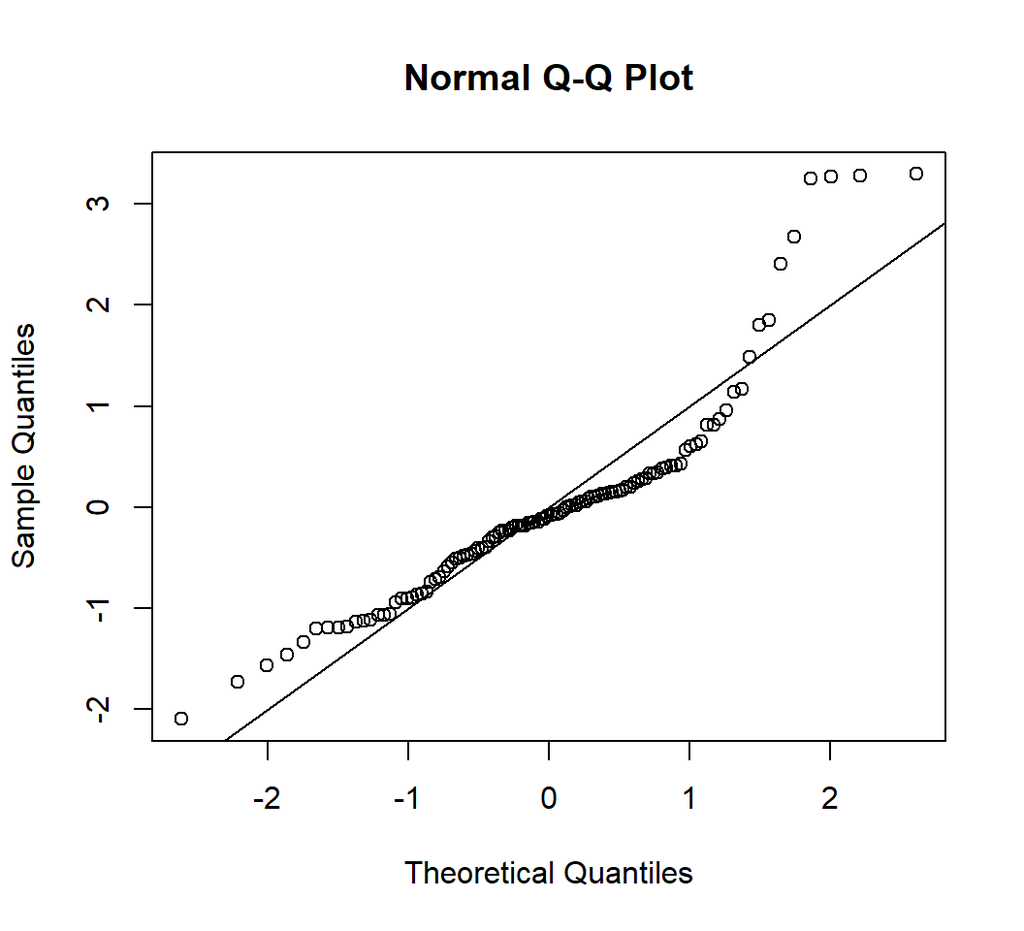

```r
m <- aov(meanTotalTime ~ taskType*inputType, data=data.long)
pander(normalCheck(m))
```

Shapiro-Wilk normality test

data: res W = 0.88212, p-value = 6.077e-08

Shapiro-Wilk normality test: `res`

| Test statistic | P value |
| --- | --- |
| 0.8821 | 6.077e-08 * * * |

The data is not normally distributed.

### 4.4.2 Box-Cox Transformation

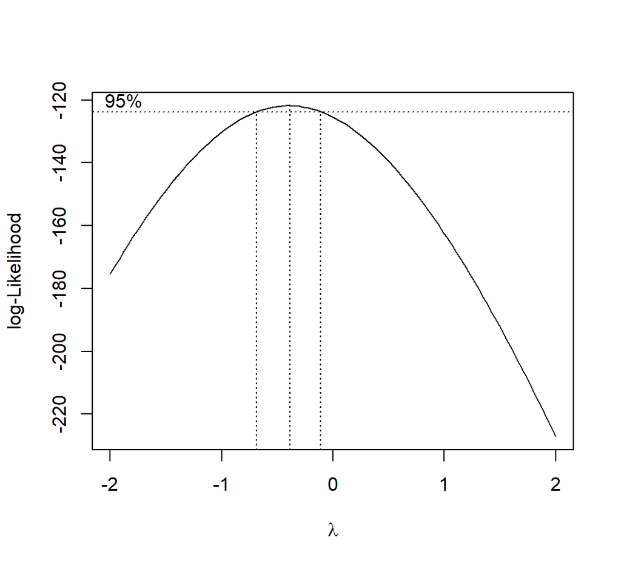

```r
boxcox(meanTotalTime ~ inputType*taskType, data=data.long, plotit=T)
```

An effective lambda value is -0.25.

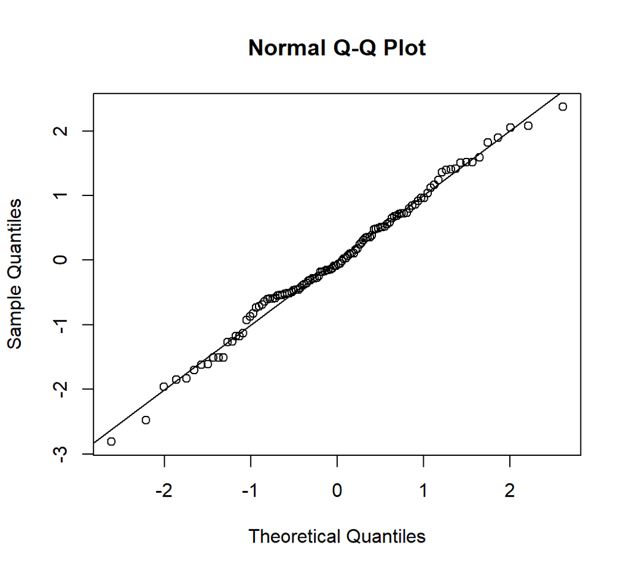

```r
datatr = data.long %>%
    mutate(meanTotalTime = meanTotalTime^(-0.25))

m <- aov(meanTotalTime ~ taskType*inputType, data=datatr)
pander(normalCheck(m))
```

Shapiro-Wilk normality test

data: res W = 0.992, p-value = 0.7626

Shapiro-Wilk normality test: `res`

| Test statistic | P value |
| --- | --- |
| 0.992 | 0.7626 |

### 4.4.3 Repeated measures ANOVA on transformed data

```r
anova = ezANOVA(datatr, dv=.(meanTotalTime), wid=.(participantNo), within=.(inputType,taskType), detailed=TRUE)

# kable(anova$`Mauchly's Test for Sphericity`)
# kable(anova$`Sphericity Corrections`)
# kable(anova$ANOVA)
anova_apa = anova_apa(anova, sph_corr ="gg", es = "ges", print=FALSE)
input = anova_apa$text[2]
task = anova_apa$text[3]
inter = anova_apa$text[4]
kable(anova_apa)
```

| effect | text |
| --- | --- |
| (Intercept) | F(1, 27) = 9941.69, p < .001, getasq > .99 |
| inputType | F(1, 27) = 115.99, p < .001, getasq = .43 |
| taskType | F(1, 27) = 185.95, p < .001, getasq = .58 |
| inputType:taskType | F(1, 27) = 37.12, p < .001, getasq = .09 |

Everything is significant.

### 4.4.4 Post-hoc analysis with Tukey HSD

```r
t <- TukeyHSD(m)
kable(t$`taskType:inputType`)
```

|  | diff | lwr | upr | p adj |
| --- | --- | --- | --- | --- |
| Transcription:Keyboard-Composition:Keyboard | 0.0104660 | 0.0060910 | 0.0148409 | 0.0000001 |
| Composition:Speech-Composition:Keyboard | 0.0067731 | 0.0023981 | 0.0111481 | 0.0005746 |
| Transcription:Speech-Composition:Keyboard | 0.0250063 | 0.0206314 | 0.0293813 | 0.0000000 |
| Composition:Speech-Transcription:Keyboard | -0.0036928 | -0.0080678 | 0.0006822 | 0.1290524 |
| Transcription:Speech-Transcription:Keyboard | 0.0145404 | 0.0101654 | 0.0189154 | 0.0000000 |
| Transcription:Speech-Composition:Speech | 0.0182332 | 0.0138582 | 0.0226082 | 0.0000000 |

```python
s = "There is a significant main effect of \\f{Input} (%s), and \\f{Task} on Box-Cox transformed \\m{Total Time} (%s). There was also a significant interaction between \\f{Input} and \\f{Task} (%s)" % (parseAnova(r.input), parseAnova(r.task), parseAnova(r.inter))
writeToFile(s, "totaltime.tex")
```

# 5 Correction Time

## 5.1 Chart

```r
kable(dplyr::select(data.stats, inputType, taskType, mCT, sdCT))
```

| inputType | taskType | mCT | sdCT |
| --- | --- | --- | --- |
| Keyboard | Composition | 3918.974 | 4912.934 |
| Keyboard | Transcription | 1820.415 | 2288.702 |
| Speech | Composition | 1720.467 | 3220.687 |
| Speech | Transcription | 1344.819 | 2601.939 |

## 5.2 Bar Graph

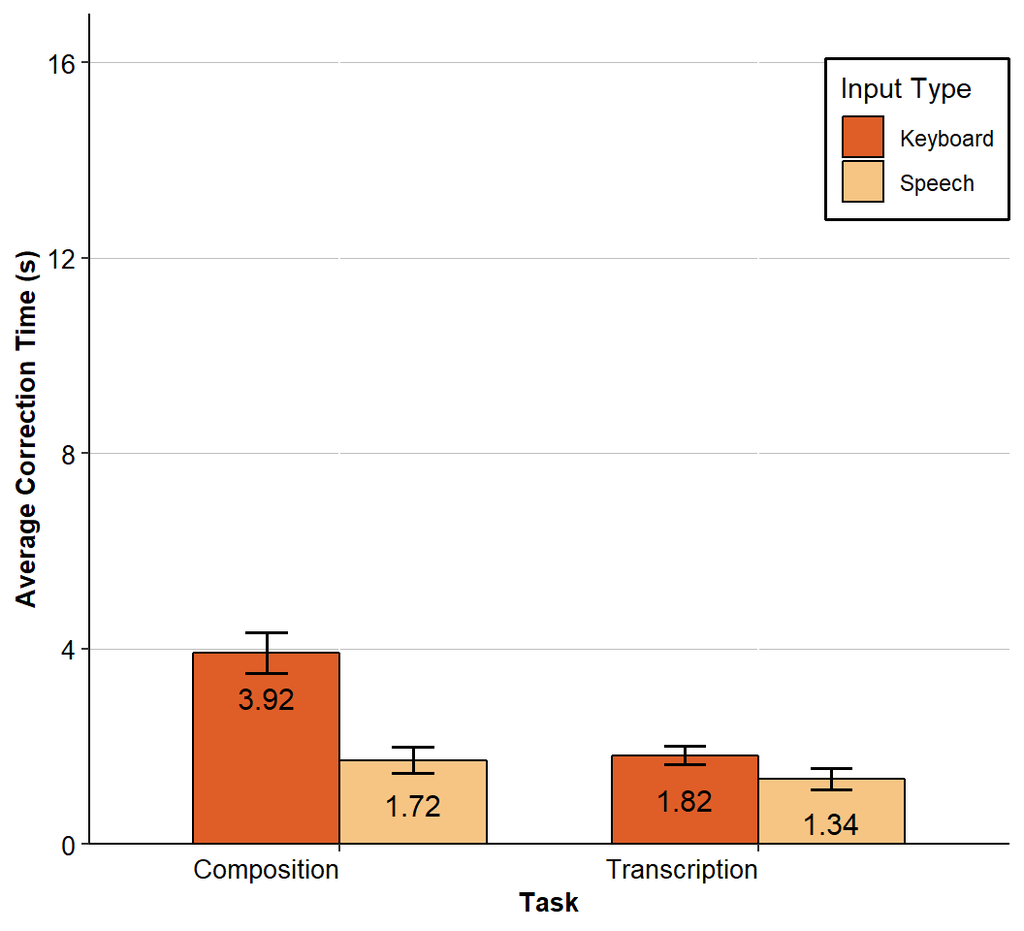

```r
createPlot(data.stats, "mCT", "clCT", "cuCT", 2.5, .9, .85, "Average Correction Time (s)", lim_min = 0, lim_max = 17)
```

```r
ggsave("autogen/corrtime.pdf")
```

## 5.3 Effects of SetNum

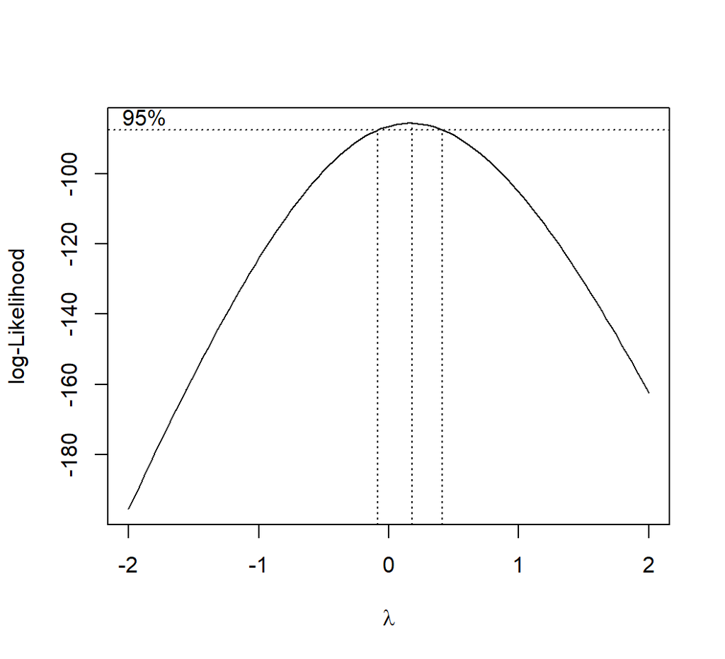

```r
boxcox(meanCorrTime ~ inputType*setNum, data=data.long.c, plotit=T)
```

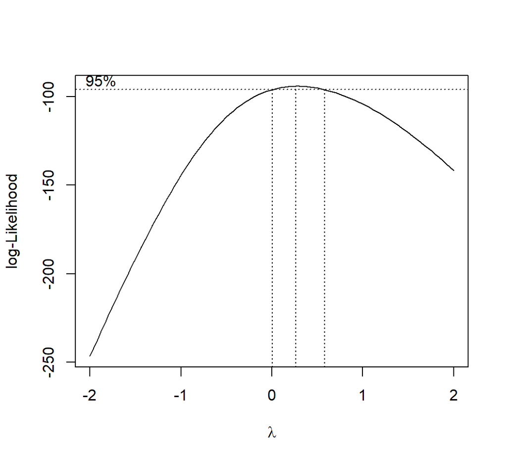

```r
boxcox(meanCorrTime ~ inputType*setNum, data=data.long.t, plotit=T)
```

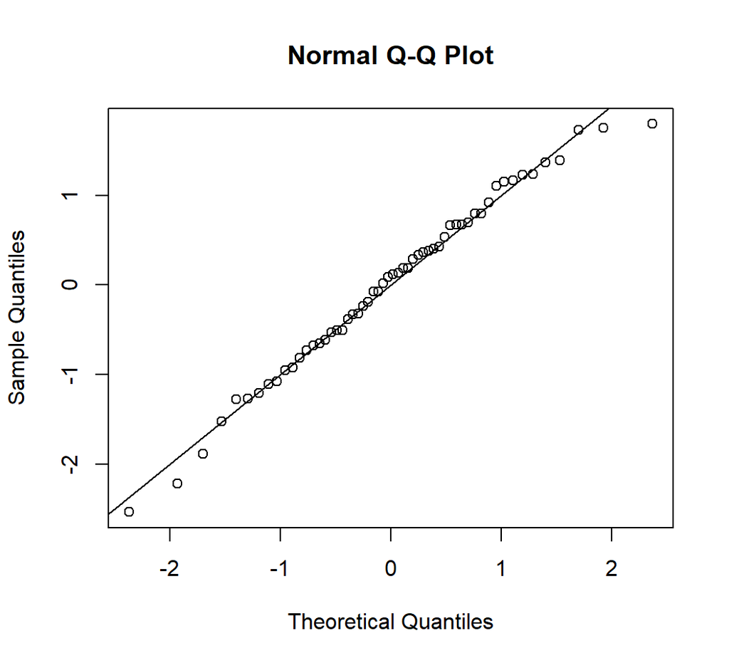

```r
datatr.c = data.long.c %>% mutate(meanCorrTime = log(meanCorrTime))
datatr.t = data.long.t %>% mutate(meanCorrTime = meanCorrTime^(0.2))

m <- aov(meanCorrTime ~ inputType*setNum, data=datatr.c)
pander(normalCheck(m))
```

Shapiro-Wilk normality test

data: res W = 0.98442, p-value = 0.6825

Shapiro-Wilk normality test: `res`

| Test statistic | P value |
| --- | --- |
| 0.9844 | 0.6825 |

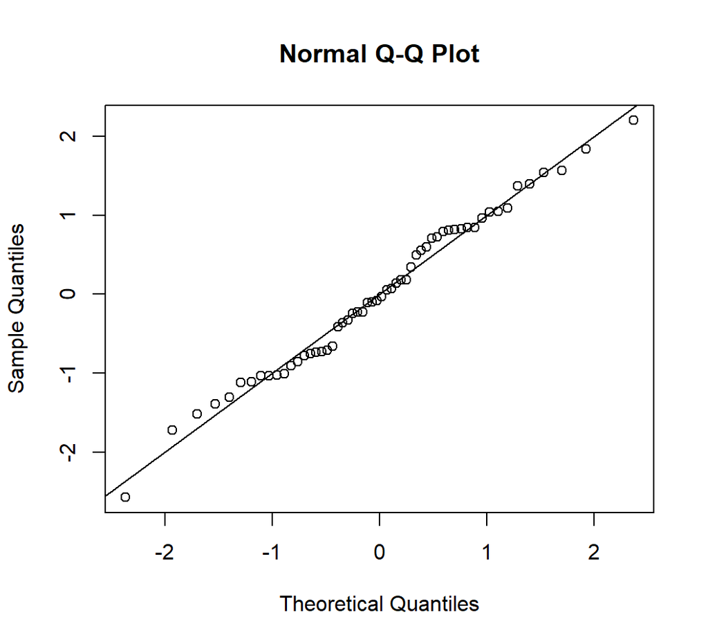

```r
m <- aov(meanCorrTime ~ setNum*inputType, data=datatr.t)
pander(normalCheck(m))
```

Shapiro-Wilk normality test

data: res W = 0.98626, p-value = 0.7718

Shapiro-Wilk normality test: `res`

| Test statistic | P value |
| --- | --- |
| 0.9863 | 0.7718 |

Data is now normally distributed.

```r
anova = ezANOVA(datatr.c, dv=.(meanCorrTime), wid=.(participantNo), within=.(setNum), detailed=TRUE)
kable(anova_apa(anova, sph_corr ="gg", es = "ges", print=FALSE))
```

| effect | text |
| --- | --- |
| (Intercept) | F(1, 27) = 5173.43, p < .001, getasq = .99 |
| setNum | F(1, 27) = 0.70, p = .410, getasq = .01 |

```r
anova = ezANOVA(datatr.t, dv=.(meanCorrTime), wid=.(participantNo), within=.(setNum), detailed=TRUE)
kable(anova_apa(anova, sph_corr ="gg", es = "ges", print=FALSE))
```

| effect | text |
| --- | --- |
| (Intercept) | F(1, 27) = 2257.12, p < .001, getasq = .98 |
| setNum | F(1, 27) = 0.37, p = .546, getasq < .01 |

No significant effect of setNum on corrTime.

## 5.4 Effects of Input Type and Task Type

### 5.4.1 Normality Check

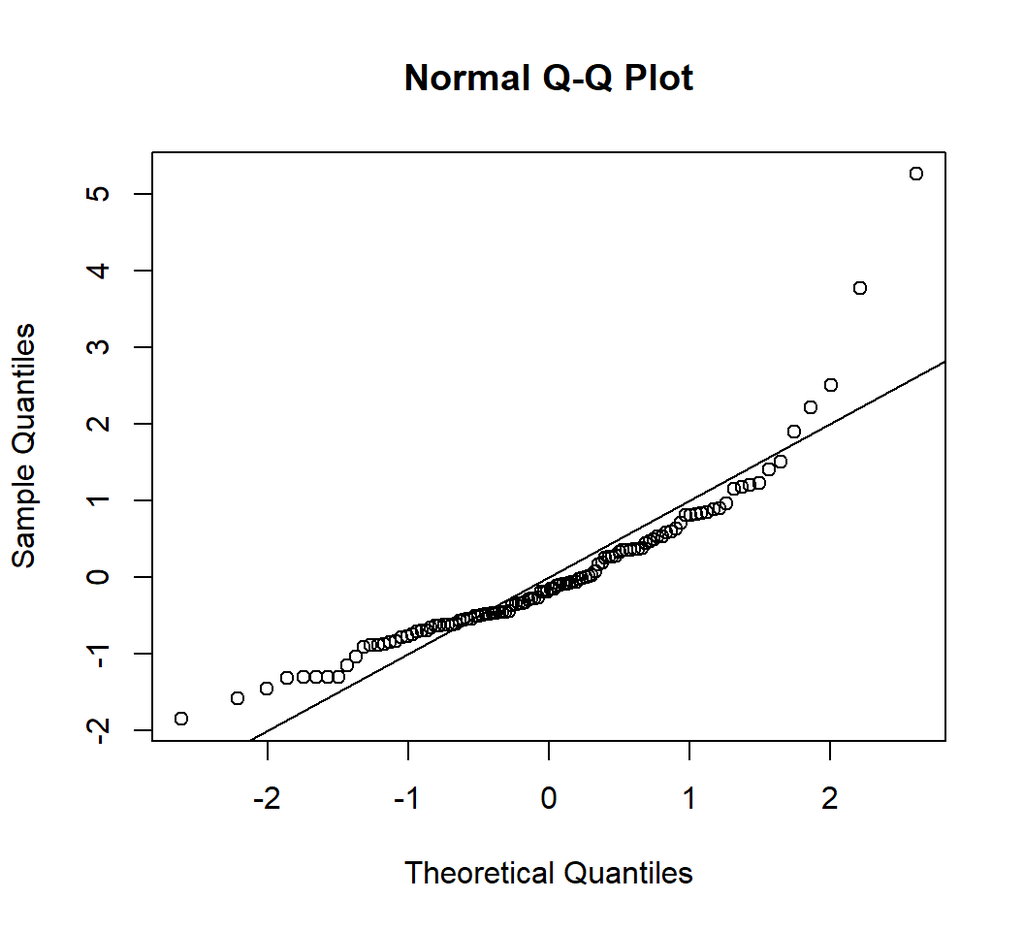

```r
m <- aov(meanCorrTime ~ taskType*inputType, data=data.long)
pander(normalCheck(m))
```

Shapiro-Wilk normality test

data: res W = 0.86519, p-value = 1.132e-08

Shapiro-Wilk normality test: `res`

| Test statistic | P value |
| --- | --- |
| 0.8652 | 1.132e-08 * * * |

The data is not normally distributed.

### 5.4.2 Box-Cox Transformation

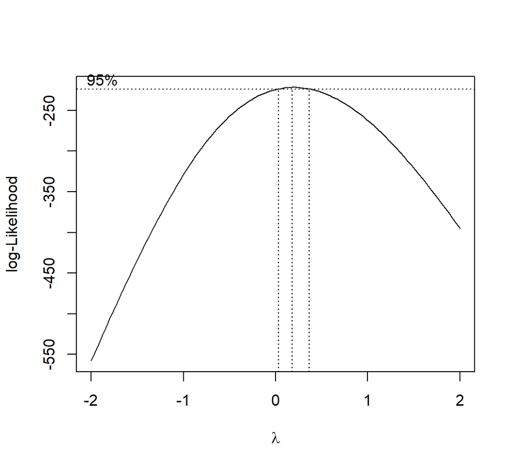

```r
boxcox(meanCorrTime ~ inputType*taskType, data=data.long, plotit=T)
```

An effective lambda value is 0.1.

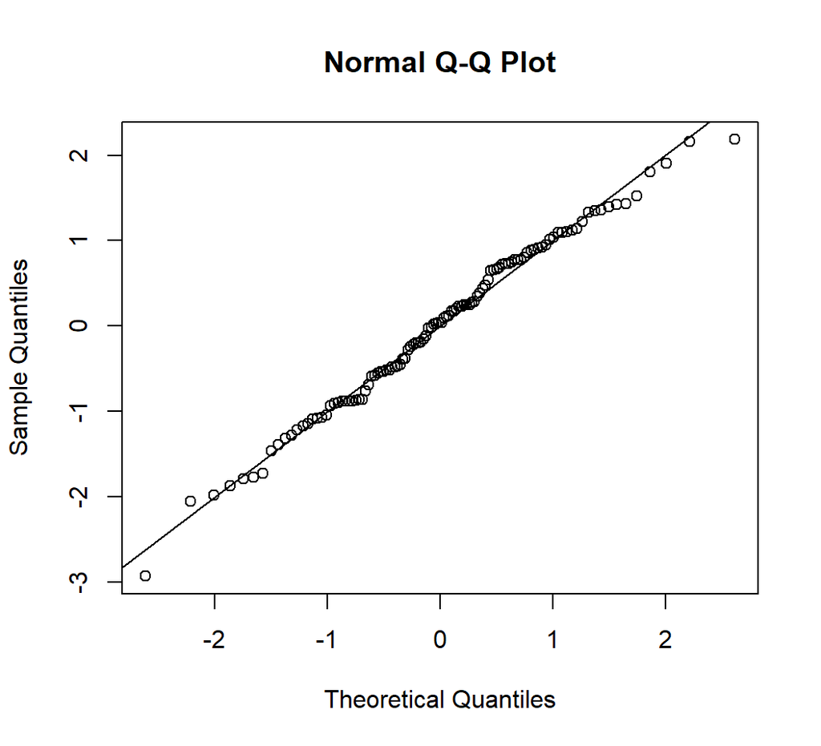

```r
datatr = data.long %>%
    mutate(meanCorrTime = meanCorrTime^(0.1))

m <- aov(meanCorrTime ~ taskType*inputType, data=datatr)
pander(normalCheck(m))
```

Shapiro-Wilk normality test

data: res W = 0.99041, p-value = 0.6215

Shapiro-Wilk normality test: `res`

| Test statistic | P value |
| --- | --- |
| 0.9904 | 0.6215 |